# 8 Exploring Overlap Between Standard Language Attitudes and Multilingualism Attitudes

Authors

Affiliations

Lars Hinrichs

The University of Texas at Austin

Stefan Dollinger

University of British Columbia

## 1 The multiling-attitudes battery

The variables that are implicated in multilingualism-attitudes and ability are:

The last one of these variables must definitely be treated separately. It does not apply to about half of all respondents, and it has 6 levels as opposed to 5 for the other 5 questions.

- `engl_able`: “Should all Canadians be taught/be able to speak English?”
- `fr_able`: “Should all Canadians be taught/be able to speak French?”
- `ind_able`: “Should all Canadians have the opportunity to learn an indigenous language?”
- `beyond_ef`: [don’t know what it means]
- `multiling`: “Is multilingualism an important feature of the Cdn. population?”
- `comf_non_eng`: “How comf. are you speaking non-En. lgs. in Can.?”

Without doubt, these variables do reflect a similar set of attitudes. The only issue is that people will rarely respond in the same way to all four of the first items above: `engl_able`, `fr_able`, `ind_able`, `beyond_ef`. These rarely shape up the same way in the same person. Nonetheless, let us explore Cronbach’s α for these.

### 1.1 Inspect distributions

After converting our multiling_vars from likert values to numeric (all 5-point), we get the following distributions.

```
                           [,1]
engl_able_num_mean    3.3594891
engl_able_num_sd      1.2022197
fr_able_num_mean      2.6404959
fr_able_num_sd        1.0401910
ind_able_num_mean     3.9566065
ind_able_num_sd       0.9125515
beyond_ef_num_mean    3.0115420
beyond_ef_num_sd      1.0661085
multiling_num_mean    3.5989941
multiling_num_sd      1.1899468
comf_non_eng_num_mean 2.4074437
comf_non_eng_num_sd   1.2843337
```

### 1.2 Compute internal consistency

Next we calculate Cronbach’s α.

**Cronbach’s α**

Rule of thumb: α ≥ .70 for research, α ≥ .80 for high‑stakes decisions (Nunnally & Bernstein, 1994).

```
Reliability analysis
Call: psych::alpha(x = df_canada[, c(multiling_vars)])

  raw_alpha std.alpha G6(smc) average_r  S/N   ase mean   sd median_r
      0.36      0.39    0.44     0.095 0.63 0.021  3.2 0.58    0.064

    95% confidence boundaries
         lower alpha upper
Feldt     0.32  0.36   0.4
Duhachek  0.32  0.36   0.4

 Reliability if an item is dropped:
                 raw_alpha std.alpha G6(smc) average_r  S/N alpha se var.r
engl_able_num         0.37      0.39    0.37     0.115 0.65    0.021 0.012
fr_able_num           0.18      0.21    0.23     0.051 0.27    0.028 0.021
ind_able_num          0.31      0.34    0.39     0.094 0.52    0.024 0.034
beyond_ef_num         0.26      0.28    0.35     0.071 0.38    0.025 0.036
multiling_num         0.35      0.36    0.40     0.101 0.56    0.022 0.032
comf_non_eng_num      0.43      0.44    0.48     0.135 0.78    0.019 0.037
                 med.r
engl_able_num    0.137
fr_able_num      0.029
ind_able_num     0.029
beyond_ef_num    0.046
multiling_num    0.047
comf_non_eng_num 0.181

 Item statistics
                    n raw.r std.r r.cor r.drop mean   sd
engl_able_num    2192  0.48  0.43 0.295  0.095  3.4 1.20
fr_able_num      2178  0.66  0.64 0.626  0.379  2.6 1.04
ind_able_num     2051  0.44  0.50 0.304  0.185  4.0 0.91
beyond_ef_num    2166  0.57  0.57 0.421  0.261  3.0 1.07
multiling_num    2187  0.49  0.47 0.276  0.127  3.6 1.19
comf_non_eng_num 1021  0.40  0.36 0.047  0.022  2.4 1.28

Non missing response frequency for each item
                    1    2    3    4    5 miss
engl_able_num    0.07 0.20 0.20 0.33 0.19 0.01
fr_able_num      0.14 0.34 0.31 0.18 0.04 0.01
ind_able_num     0.03 0.03 0.19 0.46 0.29 0.07
beyond_ef_num    0.09 0.21 0.41 0.20 0.10 0.02
multiling_num    0.06 0.16 0.18 0.35 0.26 0.01
comf_non_eng_num 0.39 0.14 0.16 0.32 0.00 0.54
```

**Internal consistency finding**

As suspected, these variables **do not combine well** into an index.

## 2 Univariate viz

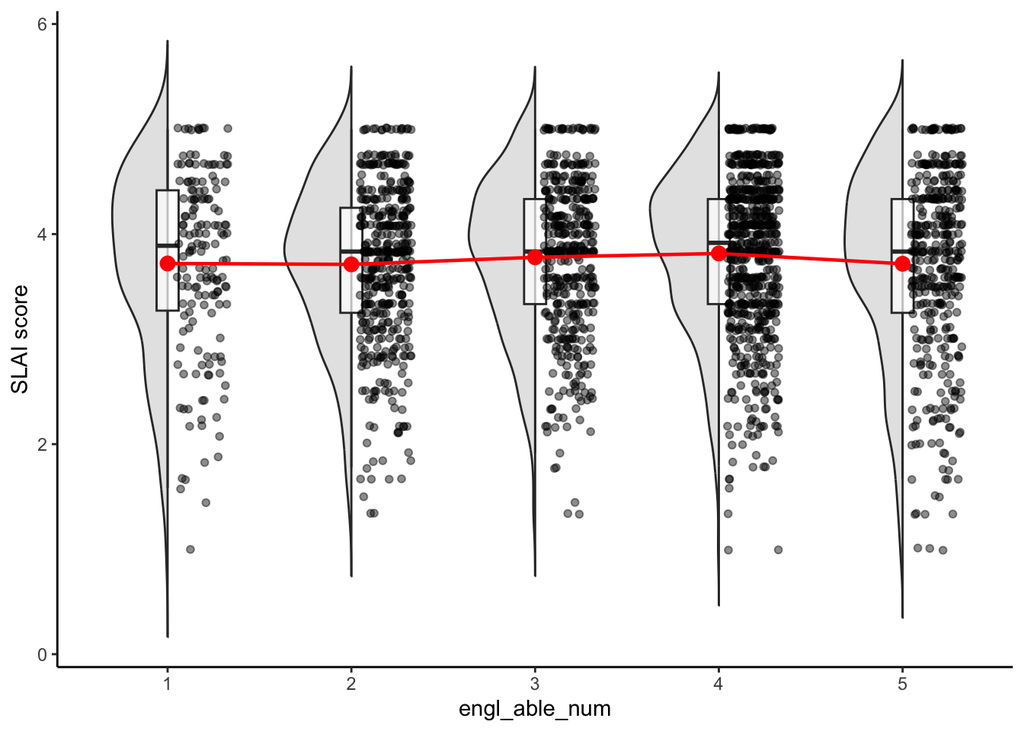

Figure 1

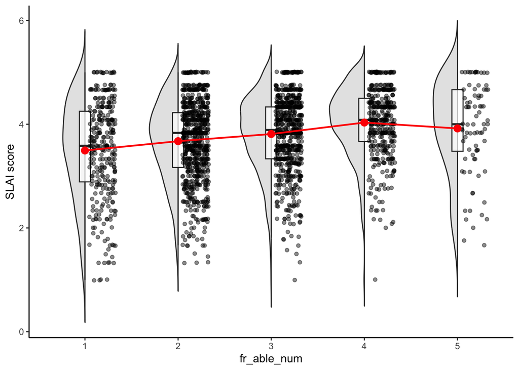

Figure 2

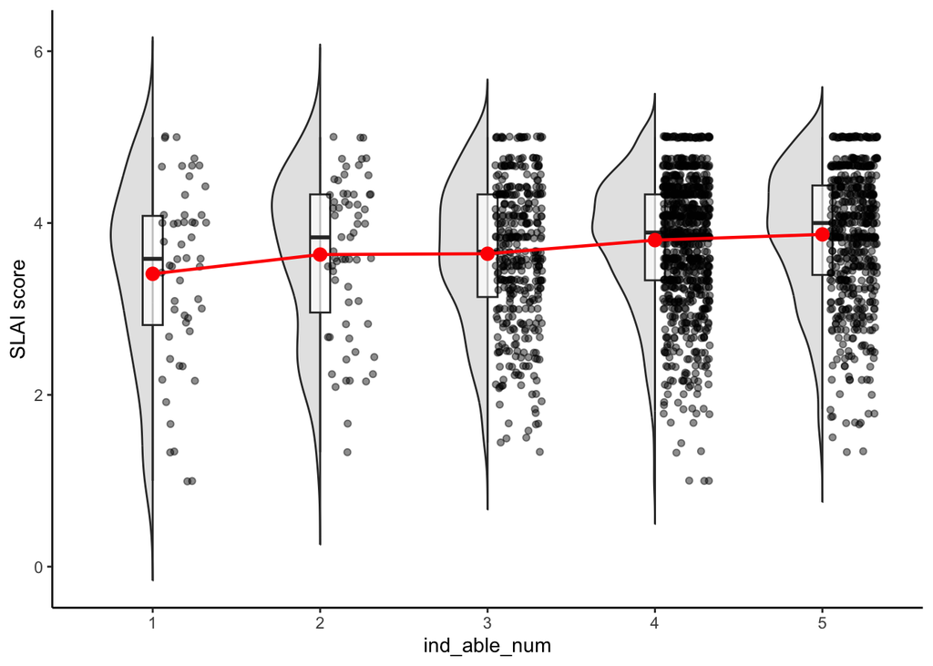

Figure 3

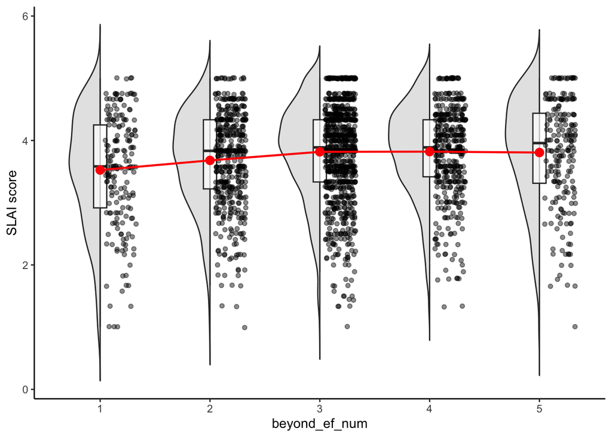

Figure 4

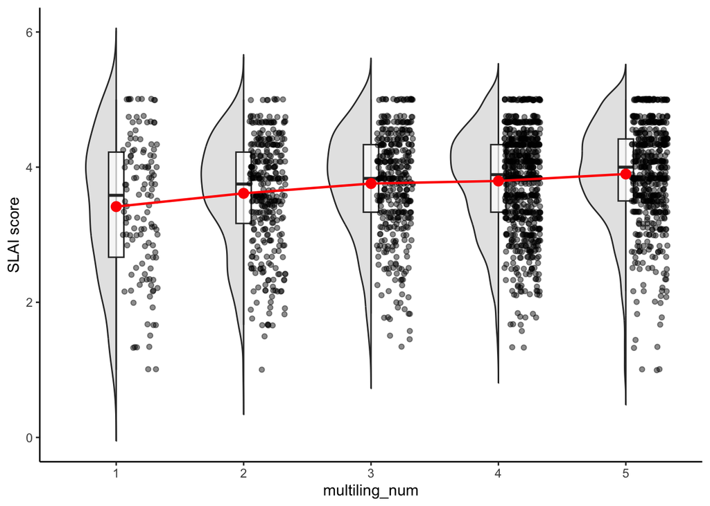

Figure 5

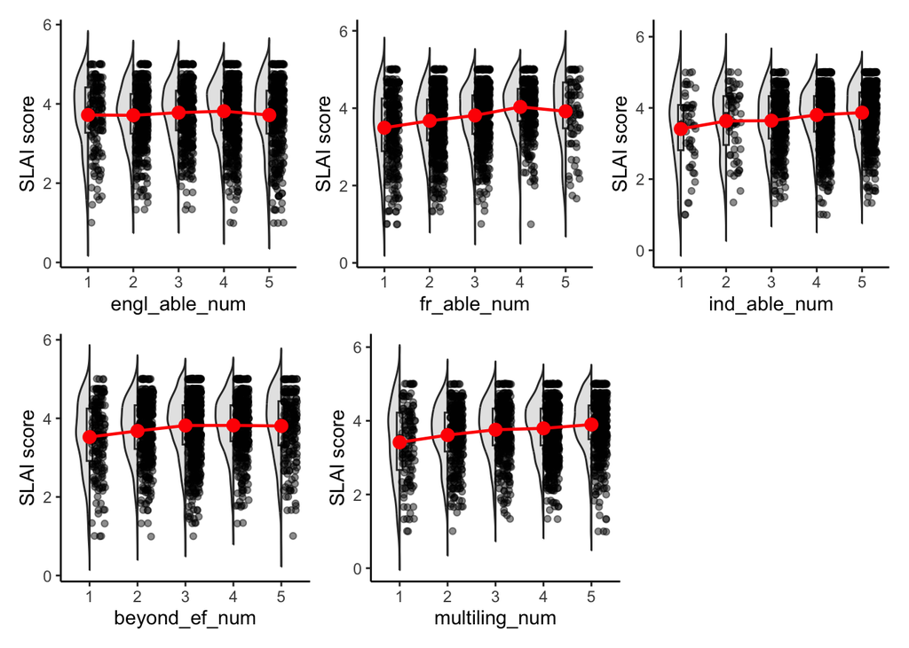

Figure 6

## 3 Significance tests for univariate correlations

| predictor | rho | p_val | n | p_value | sig |
| --- | --- | --- | --- | --- | --- |
| engl_able_num | 0.027 | .198 | 2192 | 1.983248e-01 |  |
| fr_able_num | 0.192 | < .001 | 2178 | 1.283152e-19 | *** |
| ind_able_num | 0.109 | < .001 | 2051 | 7.344693e-07 | *** |
| beyond_ef_num | 0.091 | < .001 | 2166 | 2.254696e-05 | *** |
| multiling_num | 0.131 | < .001 | 2187 | 8.006712e-10 | *** |

The key statistic here is *rho*. Explanation:

> Spearman’s ρ (rho) is a non-parametric correlation coefficient that quantifies the strength and direction of a monotonic association between two variables by comparing their ranked orders rather than their raw values. To obtain ρ, each variable is converted to ranks (handling ties by averaging ranks), and an ordinary Pearson correlation is then computed on these ranks; ρ therefore ranges from –1 (perfect inverse ordering) through 0 (no monotonic relationship) to +1 (perfect concordant ordering). Because it relies only on rank information, ρ is robust to outliers, does not require the variables to be normally distributed or linearly related, and is well-suited to ordinal data such as 1–5 ability scales. In practical terms, a high positive ρ indicates that respondents who score higher on one measure also tend to rank higher on the other, whereas a ρ near zero signals that knowing a respondent’s position on one variable gives little insight into their position on the other.

**Source:** Hauke, J., & Kossowski, T. (2011). Comparison of values of Pearson’s and Spearman’s correlation coefficients on the same sets of data. *Quaestiones Geographicae*, 30(2), 87–93. https://doi.org/10.2478/v10117-011-0021-1